# Pelatihan R pertemuan 1

Nashir Wahyudi

2 Februari 2020

## Apa itu R?

R adalah bahasa pemrograman yang dirancang khusus untuk keperluan statistik dan komputasi statistik. pertama dikembangkan pada tahun 1993 oleh **Ross Ishaka** dan **Robert Gentleman** di Auckland University New Zeeland. R bersama dengan python kini menjadi standar *de facto* bagi para statistisi dan pengembang perangkat lunak statistika.

## Seberapa populer R?

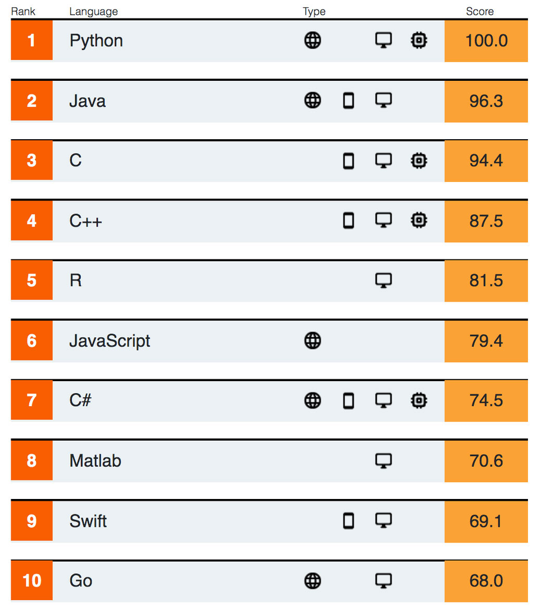

popularitas bahasa pemrograman R

R berada di peringkat ke-5 diatas bahasa pemrogaraman javascript yang berada di posisi ke-6. salah satu faktor yang membuat R begitu populer adalah banyaknya statistisi dan peeliti yang menggunakan bahasa ini dalam penelitiannya. populernya terminologi Big Data juga menjadi penyebab populernya bahasa ini.

## Kelebihan pakai R?

1. *Open-source*.
2. *Cross-platform language*.
3. Setiap orang dapat berkontribusi di R.
4. R di pakai di banyak perusahaan level dunia (Google, Microsoft, Facebook)

## Getting started with R

### Instalasi R environment

1. Buka halaman mirror web R CRAN di Indonesia pada link https://repo.bppt.go.id/cran/bin/windows/base/
2. Kemudian, klik link Download R 3.*.* for Windows (Asumsi menggunakan OS Windows), pastikan proses mengunduh selesai 100%.
3. Install file yang terdownload pada langkah ke-2 di PC/Laptop sesuai dengan versi OS yang dimiliki (64 bit atau 32 bit).
4. Jika proses instalasi telah selesai dengan benar, ikon R akan muncul pada dekstop.

### RGUI vs RStudio

- RGUI: Standar UI untuk **me-manage** R *environment* yang didapat setelah menginstall R
- Rstudio: IDE yang dirancang khusus untuk memudahkan kita dalam proses **koding** dan **project management**

## R Studio’s working area

### Source/Editor

[figure not shown]

Source image

Source/Editor window adalah jendela yang dapat digunakan untuk **membuat, mengedit, dan menyimpan** script R. Pada jendela ini, tersedia fitur autocomplete yang akan memudahkan kita dalam membuat script.

### Console

[figure not shown]

Source image

*Console window* adalah jendela tempat mengeksekusi command dari script R yang dibuat. Script tersebut dapat dijalankan dari Source/Editor window maupun dengan langsung mengetikkan script pada jendela ini. Jendela ini akan menampilkan output dari setiap satu proses/baris command R yang dijalankan.

### Environment/History/Connections

[figure not shown]

Source image

Tab environment akan menampilkan daftar data dan nilai yang sedang aktif tersimpan didalam memory (RAM). Kita dapat melihat data atau nilai tersebut dengan mengklik nama data tersebut. Tab History akan menampilkan daftar command yang telah dijalankan sebelumnya dalam satu session yang aktif. Adapun tab Connection merupakan tab khusus yang berkaitan dengan koneksi ke database seperti mySQL, postgreSQL, Spark, dll.

### Fitur Lainnya

[figure not shown]

Source image

Jendela ini merupakan fitur tambahan yang bermanfaat khususnya dalam manajemen file, menampilkan output command berupa plot, informasi dan bantuan dalam penulisan script, dan web viewer.

## Find Packages

#### Memeriksa ketersediaan packages

```r
"ggplot2" %in% installed.packages()[,'Package']
```

```
## [1] TRUE
```

cara ini bisa dilakukan dengan GUI di R studio.

#### Install

```r
install.packages("ggplot2")
```

#### Load

```r
library("ggplot2")
```

```r
require("ggplot2")
```

## Membaca data dari sumber external

File dalam format csv

```r
read.csv2("link ke data")
```

File dalam format excel

```r
require(readxl)
read_excel("alamat file")
```

File dalam format lain

```r
read.table("alamat ke file")
```

## Tipe data non-primitif di R

#### Vector

Satu atau sekulumpulan elemen dengan tipe data sama.

```r
vctr <- c(1:5)
vctr2 <- c(6:10)
```

```r
vctr * 2
```

```
## [1]  2  4  6  8 10
```

```r
vctr / 2
```

```
## [1] 0.5 1.0 1.5 2.0 2.5
```

```r
vctr + 2
```

```
## [1] 3 4 5 6 7
```

```r
vctr - 2
```

```
## [1] -1  0  1  2  3
```

```r
vctr * vctr2
```

```
## [1]  6 14 24 36 50
```

```r
vctr / vctr2
```

```
## [1] 0.1666667 0.2857143 0.3750000 0.4444444 0.5000000
```

```r
vctr + vctr2
```

```
## [1]  7  9 11 13 15
```

```r
vctr - vctr2
```

```
## [1] -5 -5 -5 -5 -5
```

```r
c(1,2) %*% c(2,3)
```

```
##      [,1]
## [1,]    8
```

#### List

list adalah sebuah objek dalam R yang dapat berisi elemen-elemen lain yang berbeda tipe datanya misal (bilangan, string, list lain, dan fungsi).

```r
vec <- c(1,2,3)
char_vec <- c("Hadoop", "Spark", "Flink", "Mahout")
logic_vec <- c(TRUE, FALSE, TRUE, FALSE)
out_list <- list(vec, char_vec, logic_vec)
```

```r
names(out_list) <- c("number", "str", "bool")
print(out_list)
```

```
## $number
## [1] 1 2 3
##
## $str
## [1] "Hadoop" "Spark"  "Flink"  "Mahout"
##
## $bool
## [1]  TRUE FALSE  TRUE FALSE
```

```r
out_list$number
```

```
## [1] 1 2 3
```

#### Array

Objek satu atau dua dimensi atau lebih pada R yang dapat menyimpan data.

```r
vector1 <- c(5,9,3)
vector2 <- c(10,11,12,13,14,15)
result <- array(c(vector1,vector2),dim = c(3,3,2))
print(result)
```

```
## , , 1
##
##      [,1] [,2] [,3]
## [1,]    5   10   13
## [2,]    9   11   14
## [3,]    3   12   15
##
## , , 2
##
##      [,1] [,2] [,3]
## [1,]    5   10   13
## [2,]    9   11   14
## [3,]    3   12   15
```

```r
result
```

```
## , , 1
##
##      [,1] [,2] [,3]
## [1,]    5   10   13
## [2,]    9   11   14
## [3,]    3   12   15
##
## , , 2
##
##      [,1] [,2] [,3]
## [1,]    5   10   13
## [2,]    9   11   14
## [3,]    3   12   15
```

### Matriks

Kumpulan bilangan yang disusun secara baris atau kolom atau kedua-duanya dan di dalam suatu tanda kurung.

```r
m1 <- matrix(1:9, nrow = 3, ncol = 3, byrow = TRUE)
m2 <- matrix(10:18, nrow = 3, ncol = 3, byrow = TRUE)

#check matriks dimmension
dim(m1)
```

```
## [1] 3 3
```

```r
#determinan
det(m1)
```

```
## [1] 6.661338e-16
```

```r
#transspose
t(m1)
```

```
##      [,1] [,2] [,3]
## [1,]    1    4    7
## [2,]    2    5    8
## [3,]    3    6    9
```

```r
#inverse
solve(m1)
```

[output not shown]

```r
#diagonal
diag(m1)
```

```
## [1] 1 5 9
```

```r
#perkalian matriks
m1 %*% m2
```

```
##      [,1] [,2] [,3]
## [1,]   84   90   96
## [2,]  201  216  231
## [3,]  318  342  366
```

```r
#Pekalian dot
m1 * m2
```

```
##      [,1] [,2] [,3]
## [1,]   10   22   36
## [2,]   52   70   90
## [3,]  112  136  162
```

### Data frame

Sebuah objek dua dimensi, dimana tiap kolom berisi kumpulan nilai dari sebuah variabel dan tiap baris beris kumpulan nilai untuk suatu entitas atau observasi.

```r
df = data.frame(
   emp_id = c (1:5),
   emp_name = c("Rick","Dan","Michelle","Ryan",NA),
   salary = c(623.3,515.2,611.0,729.0,NaN),

   start_date = as.Date(c("2012-01-01", "2013-09-23", "2014-11-15", "2014-05-11",
      "2015-03-27")),
   stringsAsFactors = FALSE
)
df
```

```
##   emp_id emp_name salary start_date
## 1      1     Rick  623.3 2012-01-01
## 2      2      Dan  515.2 2013-09-23
## 3      3 Michelle  611.0 2014-11-15
## 4      4     Ryan  729.0 2014-05-11
## 5      5     <NA>    NaN 2015-03-27
```

```r
#head
head(df)
```

```
##   emp_id emp_name salary start_date
## 1      1     Rick  623.3 2012-01-01
## 2      2      Dan  515.2 2013-09-23
## 3      3 Michelle  611.0 2014-11-15
## 4      4     Ryan  729.0 2014-05-11
## 5      5     <NA>    NaN 2015-03-27
```

```r
#tailing observation
tail(df,1)
```

```
##   emp_id emp_name salary start_date
## 5      5     <NA>    NaN 2015-03-27
```

```r
#dimension
dim(df)
```

```
## [1] 5 4
```

## Missing value detection

**Missing Value**: pada R *missing value* direpresentasikan dengan simbol NA (Not Available). Sedangkan, nilai yang tidak mungkin atau imaginer direpresentasikan dengan NaN (Not a Number).

### Mendeteksi missing value

#### Total missing value

```r
sum(is.na(df))
```

```
## [1] 2
```

#### Lokasi missing value

```r
which(is.na(df))
```

```
## [1] 10 15
```

```r
df[!complete.cases(df),]
```

```
##   emp_id emp_name salary start_date
## 5      5     <NA>    NaN 2015-03-27
```

#### Jumlah NA tiap kolom

```r
apply(df, 2, function(x) sum(is.na(x)))
```

```
##     emp_id   emp_name     salary start_date
##          0          1          1          0
```

#### Menghilangkan obeservasi dengan missing value

```r
na.omit(df)
```

```
##   emp_id emp_name salary start_date
## 1      1     Rick  623.3 2012-01-01
## 2      2      Dan  515.2 2013-09-23
## 3      3 Michelle  611.0 2014-11-15
## 4      4     Ryan  729.0 2014-05-11
```

#### Mengkodekan ulang missing value

```r
df$salary[is.na(df$salary)] <- 32
```

## Megedit nama kolom dan baris

#### Mengedit nama kolom

```r
colnames(df)
```

```
## [1] "emp_id"     "emp_name"   "salary"     "start_date"
```

```r
colnames(df) <- c('satu', 'dua', 'tiga','empat')
df
```

```
##   satu      dua  tiga      empat
## 1    1     Rick 623.3 2012-01-01
## 2    2      Dan 515.2 2013-09-23
## 3    3 Michelle 611.0 2014-11-15
## 4    4     Ryan 729.0 2014-05-11
## 5    5     <NA>  32.0 2015-03-27
```

```r
colnames(df)[3] <- "3"
df
```

```
##   satu      dua     3      empat
## 1    1     Rick 623.3 2012-01-01
## 2    2      Dan 515.2 2013-09-23
## 3    3 Michelle 611.0 2014-11-15
## 4    4     Ryan 729.0 2014-05-11
## 5    5     <NA>  32.0 2015-03-27
```

### Mengedit nama baris

```r
row.names(df)
```

```
## [1] "1" "2" "3" "4" "5"
```

```r
row.names(df) <- c('satu', 'dua', 'tiga','empat', 'lima')
df
```

```
##       satu      dua     3      empat
## satu     1     Rick 623.3 2012-01-01
## dua      2      Dan 515.2 2013-09-23
## tiga     3 Michelle 611.0 2014-11-15
## empat    4     Ryan 729.0 2014-05-11
## lima     5     <NA>  32.0 2015-03-27
```

```r
row.names(df)[3] <- "3"
df
```

```
##       satu      dua     3      empat
## satu     1     Rick 623.3 2012-01-01
## dua      2      Dan 515.2 2013-09-23
## 3        3 Michelle 611.0 2014-11-15
## empat    4     Ryan 729.0 2014-05-11
## lima     5     <NA>  32.0 2015-03-27
```

## Internal Structure of R object

```r
str(5)
```

```
##  num 5
```

```r
str(c(2,4,1,5,7))
```

```
##  num [1:5] 2 4 1 5 7
```

```r
str(df)
```

```
## 'data.frame':    5 obs. of  4 variables:
##  $ satu : int  1 2 3 4 5
##  $ dua  : chr  "Rick" "Dan" "Michelle" "Ryan" ...
##  $ 3    : num  623 515 611 729 32
##  $ empat: Date, format: "2012-01-01" "2013-09-23" ...
```

```r
summary(df)
```

```
##       satu       dua                  3             empat
##  Min.   :1   Length:5           Min.   : 32.0   Min.   :2012-01-01
##  1st Qu.:2   Class :character   1st Qu.:515.2   1st Qu.:2013-09-23
##  Median :3   Mode  :character   Median :611.0   Median :2014-05-11
##  Mean   :3                      Mean   :502.1   Mean   :2014-01-14
##  3rd Qu.:4                      3rd Qu.:623.3   3rd Qu.:2014-11-15
##  Max.   :5                      Max.   :729.0   Max.   :2015-03-27
```

Five Number Summary + Mean